# Optimal Treatment Analysis

## Outcome Variable

**Outcome Variable:** ever_stunted

## Predictor Variables

**Intervention Variable:** hhwealth_quart

**Adjustment Set:**

- arm
- sex
- W_mage
- meducyrs
- feducyrs
- W_gagebrth
- W_birthwt
- W_birthlen
- W_nchldlt5
- W_parity
- delta_W_mage
- delta_meducyrs
- delta_feducyrs
- delta_W_gagebrth
- delta_W_birthwt
- delta_W_birthlen
- delta_W_nchldlt5
- delta_W_parity

## Stratifying Variables

The analysis was stratified on these variable(s):

- agecat
- studyid
- country

## Data Summary

| agecat | studyid | country | hhwealth_quart | ever_stunted | n_cell | n |
| --- | --- | --- | --- | --- | --- | --- |
| 0-24 months | ki0047075b-MAL-ED | BANGLADESH | Wealth Q4 | 0 | 7 | 82 |
| 0-24 months | ki0047075b-MAL-ED | BANGLADESH | Wealth Q4 | 1 | 14 | 82 |
| 0-24 months | ki0047075b-MAL-ED | BANGLADESH | Wealth Q1 | 0 | 6 | 82 |
| 0-24 months | ki0047075b-MAL-ED | BANGLADESH | Wealth Q1 | 1 | 15 | 82 |
| 0-24 months | ki0047075b-MAL-ED | BANGLADESH | Wealth Q2 | 0 | 8 | 82 |
| 0-24 months | ki0047075b-MAL-ED | BANGLADESH | Wealth Q2 | 1 | 12 | 82 |
| 0-24 months | ki0047075b-MAL-ED | BANGLADESH | Wealth Q3 | 0 | 8 | 82 |
| 0-24 months | ki0047075b-MAL-ED | BANGLADESH | Wealth Q3 | 1 | 12 | 82 |
| 0-24 months | ki0047075b-MAL-ED | INDIA | Wealth Q4 | 0 | 6 | 71 |
| 0-24 months | ki0047075b-MAL-ED | INDIA | Wealth Q4 | 1 | 12 | 71 |
| 0-24 months | ki0047075b-MAL-ED | INDIA | Wealth Q1 | 0 | 9 | 71 |
| 0-24 months | ki0047075b-MAL-ED | INDIA | Wealth Q1 | 1 | 10 | 71 |
| 0-24 months | ki0047075b-MAL-ED | INDIA | Wealth Q2 | 0 | 10 | 71 |
| 0-24 months | ki0047075b-MAL-ED | INDIA | Wealth Q2 | 1 | 7 | 71 |
| 0-24 months | ki0047075b-MAL-ED | INDIA | Wealth Q3 | 0 | 4 | 71 |
| 0-24 months | ki0047075b-MAL-ED | INDIA | Wealth Q3 | 1 | 13 | 71 |
| 0-24 months | ki0047075b-MAL-ED | NEPAL | Wealth Q4 | 0 | 4 | 42 |
| 0-24 months | ki0047075b-MAL-ED | NEPAL | Wealth Q4 | 1 | 7 | 42 |
| 0-24 months | ki0047075b-MAL-ED | NEPAL | Wealth Q1 | 0 | 6 | 42 |
| 0-24 months | ki0047075b-MAL-ED | NEPAL | Wealth Q1 | 1 | 5 | 42 |
| 0-24 months | ki0047075b-MAL-ED | NEPAL | Wealth Q2 | 0 | 4 | 42 |
| 0-24 months | ki0047075b-MAL-ED | NEPAL | Wealth Q2 | 1 | 6 | 42 |
| 0-24 months | ki0047075b-MAL-ED | NEPAL | Wealth Q3 | 0 | 6 | 42 |
| 0-24 months | ki0047075b-MAL-ED | NEPAL | Wealth Q3 | 1 | 4 | 42 |
| 0-24 months | ki0047075b-MAL-ED | PERU | Wealth Q4 | 0 | 2 | 37 |
| 0-24 months | ki0047075b-MAL-ED | PERU | Wealth Q4 | 1 | 8 | 37 |
| 0-24 months | ki0047075b-MAL-ED | PERU | Wealth Q1 | 0 | 2 | 37 |
| 0-24 months | ki0047075b-MAL-ED | PERU | Wealth Q1 | 1 | 7 | 37 |
| 0-24 months | ki0047075b-MAL-ED | PERU | Wealth Q2 | 0 | 0 | 37 |
| 0-24 months | ki0047075b-MAL-ED | PERU | Wealth Q2 | 1 | 9 | 37 |

[output cut: 378 more lines]

The following strata were considered:

- agecat: 0-24 months, studyid: ki0047075b-MAL-ED, country: BANGLADESH
- agecat: 0-24 months, studyid: ki0047075b-MAL-ED, country: INDIA
- agecat: 0-24 months, studyid: ki0047075b-MAL-ED, country: NEPAL
- agecat: 0-24 months, studyid: ki0047075b-MAL-ED, country: PERU
- agecat: 0-24 months, studyid: ki0047075b-MAL-ED, country: SOUTH AFRICA
- agecat: 0-24 months, studyid: ki0047075b-MAL-ED, country: TANZANIA, UNITED REPUBLIC OF
- agecat: 0-24 months, studyid: ki1000108-CMC-V-BCS-2002, country: INDIA
- agecat: 0-24 months, studyid: ki1000108-IRC, country: INDIA
- agecat: 0-24 months, studyid: ki1017093b-PROVIDE, country: BANGLADESH
- agecat: 0-24 months, studyid: ki1066203-TanzaniaChild2, country: TANZANIA, UNITED REPUBLIC OF
- agecat: 0-24 months, studyid: ki1113344-GMS-Nepal, country: NEPAL
- agecat: 0-24 months, studyid: ki1114097-CONTENT, country: PERU
- agecat: 0-24 months, studyid: ki1135781-COHORTS, country: GUATEMALA
- agecat: 0-24 months, studyid: ki1135781-COHORTS, country: PHILIPPINES
- agecat: 0-24 months, studyid: ki1148112-LCNI-5, country: MALAWI
- agecat: 0-24 months, studyid: kiGH5241-JiVitA-3, country: BANGLADESH
- agecat: 0-24 months, studyid: kiGH5241-JiVitA-4, country: BANGLADESH
- agecat: 0-6 months, studyid: ki0047075b-MAL-ED, country: BANGLADESH
- agecat: 0-6 months, studyid: ki0047075b-MAL-ED, country: INDIA
- agecat: 0-6 months, studyid: ki0047075b-MAL-ED, country: NEPAL
- agecat: 0-6 months, studyid: ki0047075b-MAL-ED, country: PERU
- agecat: 0-6 months, studyid: ki0047075b-MAL-ED, country: SOUTH AFRICA
- agecat: 0-6 months, studyid: ki0047075b-MAL-ED, country: TANZANIA, UNITED REPUBLIC OF
- agecat: 0-6 months, studyid: ki1000108-CMC-V-BCS-2002, country: INDIA
- agecat: 0-6 months, studyid: ki1000108-IRC, country: INDIA
- agecat: 0-6 months, studyid: ki1017093b-PROVIDE, country: BANGLADESH
- agecat: 0-6 months, studyid: ki1066203-TanzaniaChild2, country: TANZANIA, UNITED REPUBLIC OF
- agecat: 0-6 months, studyid: ki1113344-GMS-Nepal, country: NEPAL
- agecat: 0-6 months, studyid: ki1114097-CONTENT, country: PERU
- agecat: 0-6 months, studyid: ki1135781-COHORTS, country: GUATEMALA
- agecat: 0-6 months, studyid: ki1135781-COHORTS, country: PHILIPPINES
- agecat: 0-6 months, studyid: ki1148112-LCNI-5, country: MALAWI
- agecat: 0-6 months, studyid: kiGH5241-JiVitA-3, country: BANGLADESH
- agecat: 0-6 months, studyid: kiGH5241-JiVitA-4, country: BANGLADESH
- agecat: 6-24 months, studyid: ki0047075b-MAL-ED, country: BANGLADESH
- agecat: 6-24 months, studyid: ki0047075b-MAL-ED, country: INDIA
- agecat: 6-24 months, studyid: ki0047075b-MAL-ED, country: NEPAL
- agecat: 6-24 months, studyid: ki0047075b-MAL-ED, country: PERU
- agecat: 6-24 months, studyid: ki0047075b-MAL-ED, country: SOUTH AFRICA
- agecat: 6-24 months, studyid: ki0047075b-MAL-ED, country: TANZANIA, UNITED REPUBLIC OF
- agecat: 6-24 months, studyid: ki1000108-CMC-V-BCS-2002, country: INDIA
- agecat: 6-24 months, studyid: ki1000108-IRC, country: INDIA
- agecat: 6-24 months, studyid: ki1017093b-PROVIDE, country: BANGLADESH
- agecat: 6-24 months, studyid: ki1066203-TanzaniaChild2, country: TANZANIA, UNITED REPUBLIC OF
- agecat: 6-24 months, studyid: ki1113344-GMS-Nepal, country: NEPAL
- agecat: 6-24 months, studyid: ki1114097-CONTENT, country: PERU
- agecat: 6-24 months, studyid: ki1135781-COHORTS, country: GUATEMALA
- agecat: 6-24 months, studyid: ki1135781-COHORTS, country: PHILIPPINES
- agecat: 6-24 months, studyid: ki1148112-LCNI-5, country: MALAWI
- agecat: 6-24 months, studyid: kiGH5241-JiVitA-3, country: BANGLADESH
- agecat: 6-24 months, studyid: kiGH5241-JiVitA-4, country: BANGLADESH

### Dropped Strata

Some strata were dropped due to rare outcomes:

- agecat: 0-24 months, studyid: ki0047075b-MAL-ED, country: INDIA
- agecat: 0-24 months, studyid: ki0047075b-MAL-ED, country: NEPAL
- agecat: 0-24 months, studyid: ki0047075b-MAL-ED, country: PERU
- agecat: 0-24 months, studyid: ki0047075b-MAL-ED, country: TANZANIA, UNITED REPUBLIC OF
- agecat: 0-6 months, studyid: ki0047075b-MAL-ED, country: BANGLADESH
- agecat: 0-6 months, studyid: ki0047075b-MAL-ED, country: NEPAL
- agecat: 0-6 months, studyid: ki0047075b-MAL-ED, country: PERU
- agecat: 0-6 months, studyid: ki0047075b-MAL-ED, country: SOUTH AFRICA
- agecat: 0-6 months, studyid: ki0047075b-MAL-ED, country: TANZANIA, UNITED REPUBLIC OF
- agecat: 6-24 months, studyid: ki0047075b-MAL-ED, country: BANGLADESH
- agecat: 6-24 months, studyid: ki0047075b-MAL-ED, country: INDIA
- agecat: 6-24 months, studyid: ki0047075b-MAL-ED, country: NEPAL
- agecat: 6-24 months, studyid: ki0047075b-MAL-ED, country: PERU
- agecat: 6-24 months, studyid: ki0047075b-MAL-ED, country: SOUTH AFRICA
- agecat: 6-24 months, studyid: ki0047075b-MAL-ED, country: TANZANIA, UNITED REPUBLIC OF
- agecat: 6-24 months, studyid: ki1114097-CONTENT, country: PERU

## Methods Detail

We’re interested in the causal parameters $E[Y_a]$ for all values of $a \in \mathcal{A}$. These parameters represent the mean outcome if, possibly contrary to fact, we intervened to set all units to have $A=a$. Under the randomization and positivity assumptions, these are identified by the statistical parameters $\psi_a=E_W[E_{Y|A,W}(Y|A=a,W)]$. In addition, we’re interested in the mean of $Y$, $E[Y]$ under no intervention (the observed mean). We will estimate these parameters by using SuperLearner to fit the relevant likelihood factors – $E_{Y|A,W}(Y|A=a,W)$ and $p(A=a|W)$, and then updating our likelihood fit using a joint TMLE.

For unadjusted analyses ($W=\{\}$), initial likelihoods were estimated using Lrnr_glm to estimate the simple $E(Y|A)$ and Lrnr_mean to estimate $p(A)$. For adjusted analyses, a small library containing Lrnr_glmnet, Lrnr_xgboost, and Lrnr_mean was used.

Having estimated these parameters, we will then use the delta method to estimate relative risks and attributable risks relative to a prespecified baseline level of $A$.

# Results Detail

## Results Plots

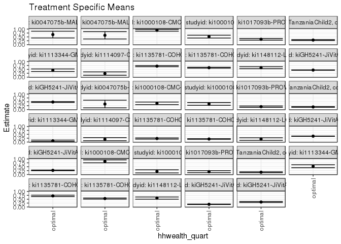

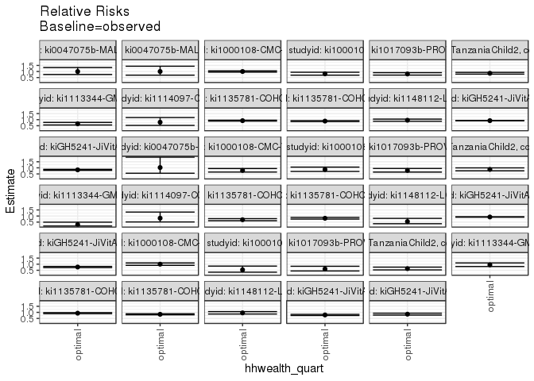

## Results Table

### Parameter: TSM

| agecat | studyid | country | intervention_level | baseline_level | estimate | ci_lower | ci_upper |
| --- | --- | --- | --- | --- | --- | --- | --- |
| 0-24 months | ki0047075b-MAL-ED | BANGLADESH | optimal | NA | 0.6486019 | 0.4326947 | 0.8645092 |
| 0-24 months | ki0047075b-MAL-ED | SOUTH AFRICA | optimal | NA | 0.6034230 | 0.3676972 | 0.8391489 |
| 0-24 months | ki1000108-CMC-V-BCS-2002 | INDIA | optimal | NA | 0.9249506 | 0.8649388 | 0.9849625 |
| 0-24 months | ki1000108-IRC | INDIA | optimal | NA | 0.5186172 | 0.4286198 | 0.6086145 |
| 0-24 months | ki1017093b-PROVIDE | BANGLADESH | optimal | NA | 0.3464486 | 0.2942838 | 0.3986134 |
| 0-24 months | ki1066203-TanzaniaChild2 | TANZANIA, UNITED REPUBLIC OF | optimal | NA | 0.2967773 | 0.2666301 | 0.3269246 |
| 0-24 months | ki1113344-GMS-Nepal | NEPAL | optimal | NA | 0.4454455 | 0.3627166 | 0.5281744 |
| 0-24 months | ki1114097-CONTENT | PERU | optimal | NA | 0.2301642 | 0.1239343 | 0.3363940 |
| 0-24 months | ki1135781-COHORTS | GUATEMALA | optimal | NA | 0.7067679 | 0.6697721 | 0.7437638 |
| 0-24 months | ki1135781-COHORTS | PHILIPPINES | optimal | NA | 0.6060429 | 0.5774534 | 0.6346323 |
| 0-24 months | ki1148112-LCNI-5 | MALAWI | optimal | NA | 0.6076327 | 0.5426312 | 0.6726341 |
| 0-24 months | kiGH5241-JiVitA-3 | BANGLADESH | optimal | NA | 0.4549104 | 0.4443300 | 0.4654907 |
| 0-24 months | kiGH5241-JiVitA-4 | BANGLADESH | optimal | NA | 0.4879515 | 0.4591034 | 0.5167997 |
| 0-6 months | ki0047075b-MAL-ED | INDIA | optimal | NA | 0.3566711 | 0.1091926 | 0.6041495 |
| 0-6 months | ki1000108-CMC-V-BCS-2002 | INDIA | optimal | NA | 0.4022749 | 0.3180129 | 0.4865370 |
| 0-6 months | ki1000108-IRC | INDIA | optimal | NA | 0.3650068 | 0.2768546 | 0.4531590 |
| 0-6 months | ki1017093b-PROVIDE | BANGLADESH | optimal | NA | 0.1879039 | 0.1451595 | 0.2306482 |
| 0-6 months | ki1066203-TanzaniaChild2 | TANZANIA, UNITED REPUBLIC OF | optimal | NA | 0.1694275 | 0.1421029 | 0.1967521 |
| 0-6 months | ki1113344-GMS-Nepal | NEPAL | optimal | NA | 0.0818492 | 0.0371337 | 0.1265646 |
| 0-6 months | ki1114097-CONTENT | PERU | optimal | NA | 0.1836119 | 0.0833510 | 0.2838729 |
| 0-6 months | ki1135781-COHORTS | GUATEMALA | optimal | NA | 0.2272002 | 0.1910542 | 0.2633463 |
| 0-6 months | ki1135781-COHORTS | PHILIPPINES | optimal | NA | 0.1948625 | 0.1741558 | 0.2155692 |
| 0-6 months | ki1148112-LCNI-5 | MALAWI | optimal | NA | 0.1923951 | 0.1094181 | 0.2753721 |
| 0-6 months | kiGH5241-JiVitA-3 | BANGLADESH | optimal | NA | 0.3787434 | 0.3695090 | 0.3879778 |
| 0-6 months | kiGH5241-JiVitA-4 | BANGLADESH | optimal | NA | 0.2676880 | 0.2469959 | 0.2883802 |
| 6-24 months | ki1000108-CMC-V-BCS-2002 | INDIA | optimal | NA | 0.8471229 | 0.7510271 | 0.9432188 |
| 6-24 months | ki1000108-IRC | INDIA | optimal | NA | 0.2030715 | 0.1029758 | 0.3031673 |
| 6-24 months | ki1017093b-PROVIDE | BANGLADESH | optimal | NA | 0.1811721 | 0.1171409 | 0.2452032 |
| 6-24 months | ki1066203-TanzaniaChild2 | TANZANIA, UNITED REPUBLIC OF | optimal | NA | 0.1450326 | 0.1156028 | 0.1744625 |
| 6-24 months | ki1113344-GMS-Nepal | NEPAL | optimal | NA | 0.5295915 | 0.4347596 | 0.6244234 |
| 6-24 months | ki1135781-COHORTS | GUATEMALA | optimal | NA | 0.7144678 | 0.6686495 | 0.7602860 |
| 6-24 months | ki1135781-COHORTS | PHILIPPINES | optimal | NA | 0.5412440 | 0.5071396 | 0.5753484 |
| 6-24 months | ki1148112-LCNI-5 | MALAWI | optimal | NA | 0.5729996 | 0.5033333 | 0.6426659 |
| 6-24 months | kiGH5241-JiVitA-3 | BANGLADESH | optimal | NA | 0.1716816 | 0.1596095 | 0.1837537 |
| 6-24 months | kiGH5241-JiVitA-4 | BANGLADESH | optimal | NA | 0.3183971 | 0.2851862 | 0.3516079 |

### Parameter: E(Y)

| agecat | studyid | country | intervention_level | baseline_level | estimate | ci_lower | ci_upper |
| --- | --- | --- | --- | --- | --- | --- | --- |
| 0-24 months | ki0047075b-MAL-ED | BANGLADESH | observed | NA | 0.6493541 | 0.5452354 | 0.7534728 |
| 0-24 months | ki0047075b-MAL-ED | SOUTH AFRICA | observed | NA | 0.6034230 | 0.4850008 | 0.7218452 |
| 0-24 months | ki1000108-CMC-V-BCS-2002 | INDIA | observed | NA | 0.9249308 | 0.8981541 | 0.9517074 |
| 0-24 months | ki1000108-IRC | INDIA | observed | NA | 0.6415364 | 0.5950593 | 0.6880135 |
| 0-24 months | ki1017093b-PROVIDE | BANGLADESH | observed | NA | 0.4349930 | 0.3981974 | 0.4717886 |
| 0-24 months | ki1066203-TanzaniaChild2 | TANZANIA, UNITED REPUBLIC OF | observed | NA | 0.3478208 | 0.3287101 | 0.3669316 |
| 0-24 months | ki1113344-GMS-Nepal | NEPAL | observed | NA | 0.6750086 | 0.6375454 | 0.7124719 |
| 0-24 months | ki1114097-CONTENT | PERU | observed | NA | 0.2920126 | 0.2310316 | 0.3529937 |
| 0-24 months | ki1135781-COHORTS | GUATEMALA | observed | NA | 0.7702778 | 0.7472500 | 0.7933055 |
| 0-24 months | ki1135781-COHORTS | PHILIPPINES | observed | NA | 0.6867080 | 0.6702618 | 0.7031541 |
| 0-24 months | ki1148112-LCNI-5 | MALAWI | observed | NA | 0.6372994 | 0.6043198 | 0.6702790 |
| 0-24 months | kiGH5241-JiVitA-3 | BANGLADESH | observed | NA | 0.4946196 | 0.4867696 | 0.5024696 |
| 0-24 months | kiGH5241-JiVitA-4 | BANGLADESH | observed | NA | 0.5845928 | 0.5686037 | 0.6005819 |
| 0-6 months | ki0047075b-MAL-ED | INDIA | observed | NA | 0.3482277 | 0.2363381 | 0.4601173 |
| 0-6 months | ki1000108-CMC-V-BCS-2002 | INDIA | observed | NA | 0.5128325 | 0.4616900 | 0.5639751 |
| 0-6 months | ki1000108-IRC | INDIA | observed | NA | 0.4222125 | 0.3743127 | 0.4701122 |
| 0-6 months | ki1017093b-PROVIDE | BANGLADESH | observed | NA | 0.2392862 | 0.2076138 | 0.2709587 |
| 0-6 months | ki1066203-TanzaniaChild2 | TANZANIA, UNITED REPUBLIC OF | observed | NA | 0.1952261 | 0.1793171 | 0.2111352 |
| 0-6 months | ki1113344-GMS-Nepal | NEPAL | observed | NA | 0.2794354 | 0.2436408 | 0.3152299 |
| 0-6 months | ki1114097-CONTENT | PERU | observed | NA | 0.2231305 | 0.1673372 | 0.2789237 |
| 0-6 months | ki1135781-COHORTS | GUATEMALA | observed | NA | 0.3273202 | 0.2988220 | 0.3558185 |
| 0-6 months | ki1135781-COHORTS | PHILIPPINES | observed | NA | 0.2396720 | 0.2245489 | 0.2547950 |
| 0-6 months | ki1148112-LCNI-5 | MALAWI | observed | NA | 0.3539781 | 0.2967559 | 0.4112004 |
| 0-6 months | kiGH5241-JiVitA-3 | BANGLADESH | observed | NA | 0.4113765 | 0.4039248 | 0.4188282 |
| 0-6 months | kiGH5241-JiVitA-4 | BANGLADESH | observed | NA | 0.3493309 | 0.3341218 | 0.3645400 |
| 6-24 months | ki1000108-CMC-V-BCS-2002 | INDIA | observed | NA | 0.8474070 | 0.7956229 | 0.8991911 |
| 6-24 months | ki1000108-IRC | INDIA | observed | NA | 0.3777021 | 0.3157358 | 0.4396685 |
| 6-24 months | ki1017093b-PROVIDE | BANGLADESH | observed | NA | 0.2991547 | 0.2570458 | 0.3412636 |
| 6-24 months | ki1066203-TanzaniaChild2 | TANZANIA, UNITED REPUBLIC OF | observed | NA | 0.2284204 | 0.2078688 | 0.2489721 |
| 6-24 months | ki1113344-GMS-Nepal | NEPAL | observed | NA | 0.5605073 | 0.5133267 | 0.6076880 |
| 6-24 months | ki1135781-COHORTS | GUATEMALA | observed | NA | 0.7659783 | 0.7374878 | 0.7944688 |
| 6-24 months | ki1135781-COHORTS | PHILIPPINES | observed | NA | 0.6448950 | 0.6245255 | 0.6652645 |
| 6-24 months | ki1148112-LCNI-5 | MALAWI | observed | NA | 0.5991997 | 0.5631393 | 0.6352601 |
| 6-24 months | kiGH5241-JiVitA-3 | BANGLADESH | observed | NA | 0.2180343 | 0.2086765 | 0.2273921 |
| 6-24 months | kiGH5241-JiVitA-4 | BANGLADESH | observed | NA | 0.3739943 | 0.3552924 | 0.3926962 |

### Parameter: RR

| agecat | studyid | country | intervention_level | baseline_level | estimate | ci_lower | ci_upper |
| --- | --- | --- | --- | --- | --- | --- | --- |
| 0-24 months | ki0047075b-MAL-ED | BANGLADESH | optimal | observed | 0.9988417 | 0.7516324 | 1.3273574 |
| 0-24 months | ki0047075b-MAL-ED | SOUTH AFRICA | optimal | observed | 1.0000000 | 0.6977709 | 1.4331352 |
| 0-24 months | ki1000108-CMC-V-BCS-2002 | INDIA | optimal | observed | 1.0000214 | 0.9472595 | 1.0557221 |
| 0-24 months | ki1000108-IRC | INDIA | optimal | observed | 0.8083987 | 0.6977008 | 0.9366600 |
| 0-24 months | ki1017093b-PROVIDE | BANGLADESH | optimal | observed | 0.7964463 | 0.7012187 | 0.9046060 |
| 0-24 months | ki1066203-TanzaniaChild2 | TANZANIA, UNITED REPUBLIC OF | optimal | observed | 0.8532477 | 0.7836572 | 0.9290180 |
| 0-24 months | ki1113344-GMS-Nepal | NEPAL | optimal | observed | 0.6599108 | 0.5615759 | 0.7754647 |
| 0-24 months | ki1114097-CONTENT | PERU | optimal | observed | 0.7881994 | 0.5291066 | 1.1741648 |
| 0-24 months | ki1135781-COHORTS | GUATEMALA | optimal | observed | 0.9175494 | 0.8831619 | 0.9532759 |
| 0-24 months | ki1135781-COHORTS | PHILIPPINES | optimal | observed | 0.8825336 | 0.8495792 | 0.9167663 |
| 0-24 months | ki1148112-LCNI-5 | MALAWI | optimal | observed | 0.9534492 | 0.8697164 | 1.0452435 |
| 0-24 months | kiGH5241-JiVitA-3 | BANGLADESH | optimal | observed | 0.9197176 | 0.9049789 | 0.9346963 |
| 0-24 months | kiGH5241-JiVitA-4 | BANGLADESH | optimal | observed | 0.8346863 | 0.7947997 | 0.8765745 |
| 0-6 months | ki0047075b-MAL-ED | INDIA | optimal | observed | 1.0242466 | 0.5582492 | 1.8792345 |
| 0-6 months | ki1000108-CMC-V-BCS-2002 | INDIA | optimal | observed | 0.7844177 | 0.6529948 | 0.9422910 |
| 0-6 months | ki1000108-IRC | INDIA | optimal | observed | 0.8645098 | 0.7052561 | 1.0597244 |
| 0-6 months | ki1017093b-PROVIDE | BANGLADESH | optimal | observed | 0.7852683 | 0.6502565 | 0.9483125 |
| 0-6 months | ki1066203-TanzaniaChild2 | TANZANIA, UNITED REPUBLIC OF | optimal | observed | 0.8678525 | 0.7546812 | 0.9979947 |
| 0-6 months | ki1113344-GMS-Nepal | NEPAL | optimal | observed | 0.2929092 | 0.1744145 | 0.4919073 |
| 0-6 months | ki1114097-CONTENT | PERU | optimal | observed | 0.8228904 | 0.5115201 | 1.3237968 |
| 0-6 months | ki1135781-COHORTS | GUATEMALA | optimal | observed | 0.6941221 | 0.6129592 | 0.7860319 |
| 0-6 months | ki1135781-COHORTS | PHILIPPINES | optimal | observed | 0.8130383 | 0.7458956 | 0.8862249 |
| 0-6 months | ki1148112-LCNI-5 | MALAWI | optimal | observed | 0.5435225 | 0.3666593 | 0.8056980 |
| 0-6 months | kiGH5241-JiVitA-3 | BANGLADESH | optimal | observed | 0.9206734 | 0.9056129 | 0.9359845 |
| 0-6 months | kiGH5241-JiVitA-4 | BANGLADESH | optimal | observed | 0.7662879 | 0.7190552 | 0.8166233 |
| 6-24 months | ki1000108-CMC-V-BCS-2002 | INDIA | optimal | observed | 0.9996648 | 0.9063378 | 1.1026017 |
| 6-24 months | ki1000108-IRC | INDIA | optimal | observed | 0.5376499 | 0.3429003 | 0.8430074 |
| 6-24 months | ki1017093b-PROVIDE | BANGLADESH | optimal | observed | 0.6056133 | 0.4412048 | 0.8312861 |
| 6-24 months | ki1066203-TanzaniaChild2 | TANZANIA, UNITED REPUBLIC OF | optimal | observed | 0.6349373 | 0.5311559 | 0.7589964 |
| 6-24 months | ki1113344-GMS-Nepal | NEPAL | optimal | observed | 0.9448432 | 0.8089097 | 1.1036196 |
| 6-24 months | ki1135781-COHORTS | GUATEMALA | optimal | observed | 0.9327519 | 0.8896211 | 0.9779738 |
| 6-24 months | ki1135781-COHORTS | PHILIPPINES | optimal | observed | 0.8392746 | 0.7975371 | 0.8831963 |
| 6-24 months | ki1148112-LCNI-5 | MALAWI | optimal | observed | 0.9562748 | 0.8625735 | 1.0601550 |
| 6-24 months | kiGH5241-JiVitA-3 | BANGLADESH | optimal | observed | 0.7874062 | 0.7412556 | 0.8364300 |
| 6-24 months | kiGH5241-JiVitA-4 | BANGLADESH | optimal | observed | 0.8513421 | 0.7771052 | 0.9326708 |